# 2. Quality control

Cankun Wang

04/07/2021

# 1 Set working dir

```
## [1] "Current working directory: C:/Users/flyku/Documents/GitHub/NOTCH1-scRNAseq"
```

# 2 Load data

# 3 Number of cells of the original data

```
##
##   Con0  Con10  Con14   Con2  Con30   Con5  N1KO0 N1KO10 N1KO14  N1KO2 N1KO30
##   4645   2910   1619   3349   2192   2004   2964   3020   2716   3435   1638
##  N1KO5
##   1697
```

```
##  [1] "RPL22"       "RPL11"       "RPS6KA1"     "RPS8"        "RPL5"
##  [6] "RPS27"       "RPS6KC1"     "RPS7"        "RPS27A"      "RPL31"
## [11] "RPL37A"      "RPL32"       "RPL15"       "RPL14"       "RPL29"
## [16] "RPL24"       "RPL22L1"     "RPL39L"      "RPL35A"      "RPL9"
## [21] "RPL34"       "RPS3A"       "RPL37"       "RPS23"       "RPS14"
## [26] "RPL26L1"     "RPS18"       "RPS10-NUDT3" "RPS10"       "RPL10A"
## [31] "RPL7L1"      "RPS12"       "RPS6KA2"     "RPS6KA2-IT1" "RPS20"
## [36] "RPL7"        "RPL30"       "RPL8"        "RPS6"        "RPL35"
## [41] "RPL12"       "RPL7A"       "RPS24"       "RPL27A"      "RPS13"
## [46] "RPS6KA4"     "RPS6KB2"     "RPS3"        "RPS25"       "RPS26"
## [51] "RPL41"       "RPL6"        "RPL21"       "RPS29"       "RPL36AL"
## [56] "RPS6KL1"     "RPS6KA5"     "RPS27L"      "RPL4"        "RPS17"
## [61] "RPL3L"       "RPS2"        "RPS15A"      "RPL13"       "RPL26"
## [66] "RPL23A"      "RPL23"       "RPL19"       "RPL27"       "RPS6KB1"
## [71] "RPL38"       "RPL17"       "RPS15"       "RPL36"       "RPS28"
## [76] "RPL18A"      "RPS16"       "RPS19"       "RPL18"       "RPL13A"
## [81] "RPS11"       "RPS9"        "RPL28"       "RPS5"        "RPS21"
## [86] "RPL3"        "RPS19BP1"    "RPS6KA3"     "RPS4X"       "RPS6KA6"
## [91] "RPL36A"      "RPL39"       "RPL10"       "RPL34-AS1"   "RPL10L"
```

# 4 Mitochondrial genes

```
##  [1] "MT-ND1"  "MT-ND2"  "MT-CO1"  "MT-CO2"  "MT-ATP8" "MT-ATP6" "MT-CO3"
##  [8] "MT-ND3"  "MT-ND4L" "MT-ND4"  "MT-ND5"  "MT-ND6"  "MT-CYB"
```

# 5 Plot QC

Citing from “Simple Single Cell” workflows (Lun, McCarthy & Marioni, 2017): “High proportions are indicative of poor-quality cells (Islam et al. 2014; Ilicic et al. 2016), possibly because of loss of cytoplasmic RNA from perforated cells. The reasoning is that mitochondria are larger than individual transcript molecules and less likely to escape through tears in the cell membrane.”

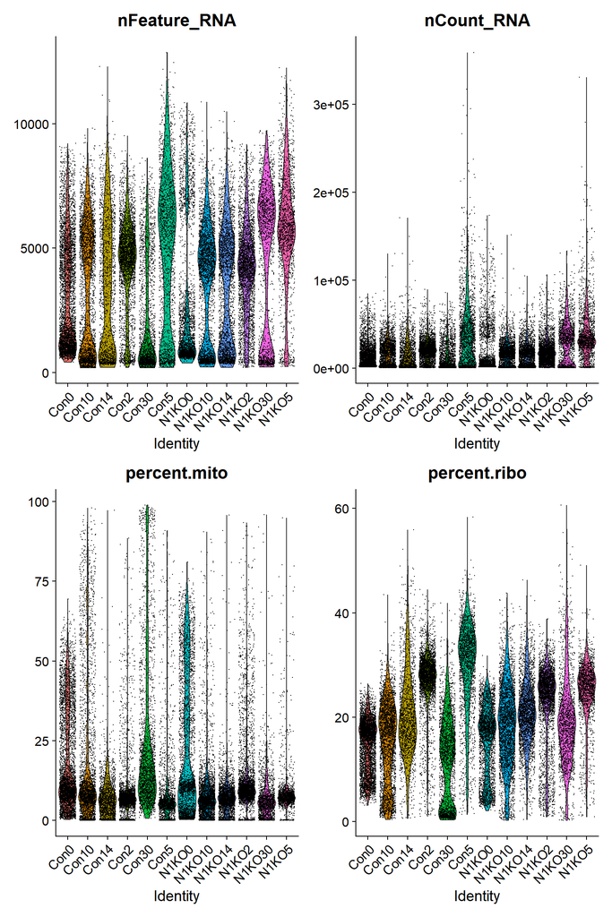

# 6 Filter cells and plot after QC

Similar to [Single cell transcriptomic analysis of cardiac differentiation from human PSCs reveals HOPX-dependent cardiomyocyte maturation](https://www.ncbi.nlm.nih.gov/pmc/articles/PMC6220122/).

We filtered outlier genes and cells which were outside the range of 5x median absolute deviation (MAD) of the number of cells with ribosomal reads, mitochondrial reads, and total read mapped to cells to remove noise due to sequencing depth or cell conditions. Further, cells with above 50% ribosomal reads, or above 30% mitochondrial reads, and genes detected in fewer than 3 cells were also removed.

Since we want to perform QC as permissive of QC thresholding as possible, we can revisit QC if downstream clustering cannot be interpreted.

These cells are removed:

- Cells with above 50% ribosomal reads
- Cells with above 30% mitochondrial reads
- Cells detected less than 200 genes
- Cells with total counts outside 5x MAD

These genes were removed:

- Genes detected in fewer than 3 cells

# 7 Number of cells

```
## [1] "before QC: 32189"
```

```
##
##   Con0  Con10  Con14   Con2  Con30   Con5  N1KO0 N1KO10 N1KO14  N1KO2 N1KO30
##   4645   2910   1619   3349   2192   2004   2964   3020   2716   3435   1638
##  N1KO5
##   1697
```

```
## [1] "after QC: 27532"
```

```
##
##   Con0  Con10  Con14   Con2  Con30   Con5  N1KO0 N1KO10 N1KO14  N1KO2 N1KO30
##   3430   2297   1588   3194   1643   1733   1849   2875   2685   3056   1596
##  N1KO5
##   1586
```

# 8 Plot data after QC

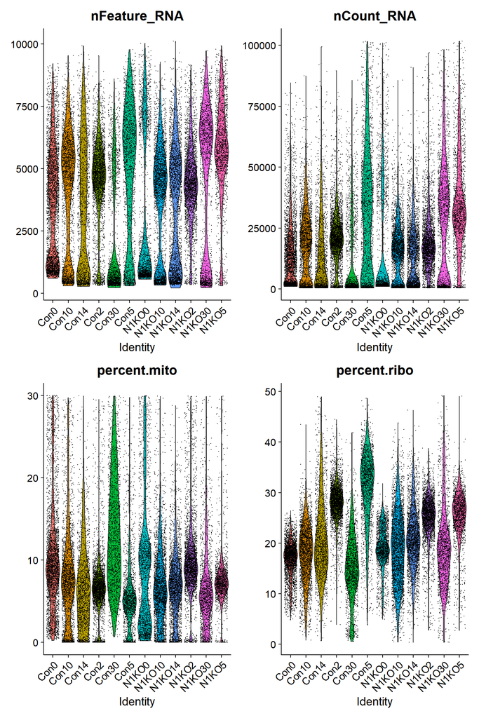

# 9 Cell-cycle scores

We here perform cell cycle scoring. To score a gene list, the algorithm calculates the difference of mean expression of the given list and the mean expression of reference genes. To build the reference, the function randomly chooses a bunch of genes matching the distribution of the expression of the given list. Cell cycle scoring adds three slots in data, a score for S phase, a score for G2M phase and the predicted cell cycle phase.

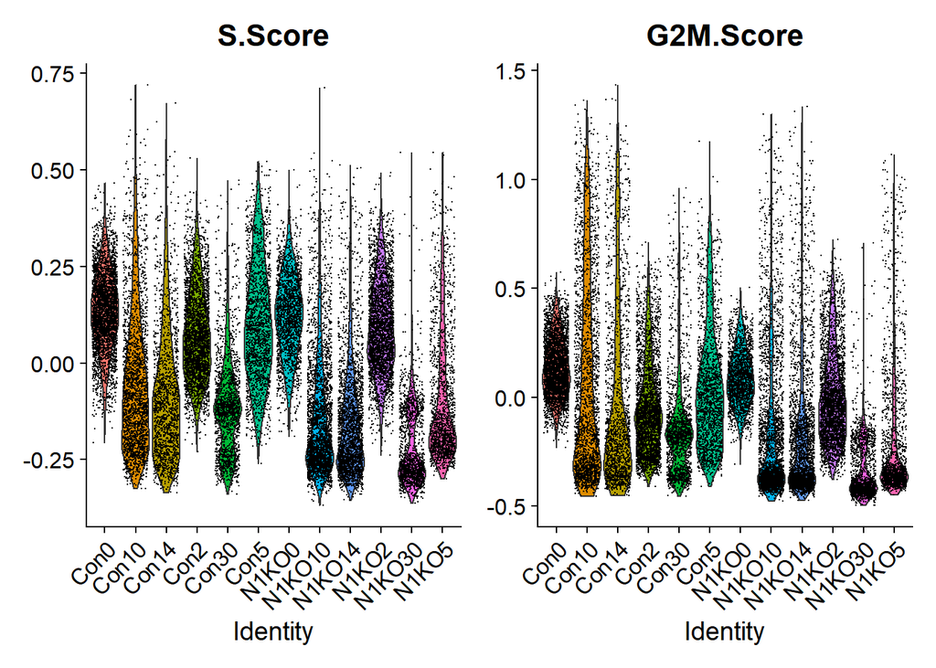